# Synthèse individuelle

L’impact environnemental du numérique

DURIEUX Marie

09 février 2023

A l’heure où les débats sur l’environnement sont de plus en plus présent, le numérique est pointé du doigt. En effet, son impact environnemental, appelé aussi pollution numérique est un sujet au coeur de l’actualité.

Mais avant de discuter de ce sujet, il est utile de comprendre le numérique. Au milieu XXème siècle, l’ère du numérique a démarré avec l’apparition de la technologie de l’information. Petit à petit, les nouvelles technologies ont modifié l’industrie traditionnelle mise en place lors de la révolution industrielle. L’apparition de cette ère est en corrélation avec les nombreux développements de la technologie de l’information et de la communication comme les développements des transistors. Cela a permi le développement du microprocesseur qui constituent le composant actif le plus important des circuits électroniques nécessaires notamment aux matériels informatiques (Wikipedia, 2022) Ces évolutions ont permis :

- D’avoir un accès immédiat aux informations
- D’avoir un accès à de très grandes quantités d’informations
- De stocker ses données
- De partager et transmettre ses données
- De dématérialiser des processus, autrement dit de produire directement les informations au format numérique à partir d’un système d’information ce qui ne nécessite pas de support physique.
- Ect…

Alors que les technologies de l’information et de la communication se développent, la pollution numérique émerge et devient un problème majeur de l’ère du numérique. Bien que les impacts ne sont pas visibles directement, le numérique représente une part importante de la pollution nationale et mondiale.

# 1 Qu’est ce que la pollution numérique?

En quelques mots, toutes les formes de pollution pouvant être engendrées par le secteur informatique constituent la pollution numérique. Dans le secteur informatique, il existe de très nombreuses activités numériques tels que les différentes technologies de l’information et de la communication. Elles peuvent être matériels ou immatériels. Souvent, les activités numériques ne sont pas visibles. Même si ces activités aient entrainé des évolutions majeures permettant parfois l’amélioration des conditions de vie, elles sont aussi sources d’impact sur l’environnement. Cela est appelé la pollution numérique. La pollution numérique peut également est importée. Par exemple, la France est responsable de pollution importée puisque de nombreuses activités se font en dehors de ses territoires.

Il existe différents types d’activités du numérique et la pollution numérique peut être de différents types.

Il est possible de considerer 3 phases dans le cycle de vie d’un appareil numérique:

- La fabrication
- L’utilisation
- La fin de vie

C’est l’étape de fabrication qui consomme le plus d’energie, de ressources et ainsi qui est la plus polluante.

# 2 Les activités du numérique

Les impacts environnementaux des activités du numérique (ARCEP, 2023) :

- 70% des impacts environnementaux : les appareils numériques (ou terminaux) (écrans, téléviseurs, …)
- 20% des impacts environnementaux : les centres de données
- 10% des impacts environnementaux : les réseaux

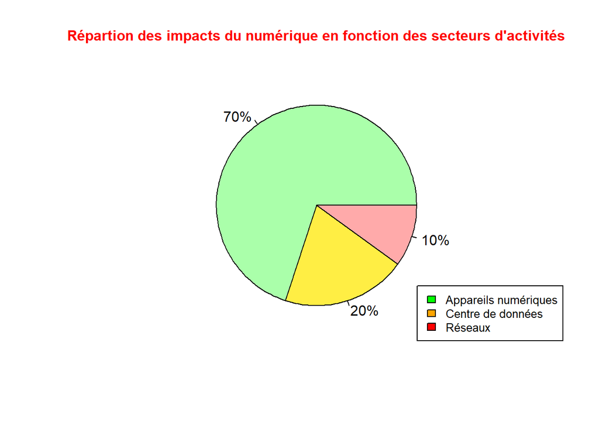

```r
knitr::opts_chunk$set(echo = FALSE, eval= TRUE)
library(scales)
valeurs <- c(0.70, 0.20, 0.10)

pie<-pie(valeurs,
    col=c("#AAFFAA","#FFEE44","#FFAAAA"),
    main = "Répartion des impacts du numérique en fonction des secteurs d'activités",
    col.main="red",
    cex.main=1,
    cex=1,
    label= percent(valeurs))
legend(x="bottomright", legend=c("Appareils numériques","Centre de données","Réseaux"), cex=0.8,fill=c("green","orange","red"))
```

- Ordinateurs de bureaux
- Ordinateurs portables
- Téléviseurs
- Smartphones
- Smartwatches
- Serveurs
- Etc….

Les appareils numériques polluent tout au long de leur cycle de vie : de leur fabrication à leur fin de vie. Avec une émission de 78% de CO2, la fabrication des terminaux numériques est le principal émetteur de CO2 (Inoxia, 2021). Pour fabriquer des appareils, de nombreux éléments sont nécessaires comme :

- Des ressources : des métaux en provenance du monde entier
- De l’eau pour extraire les minerais
- De l’énergie

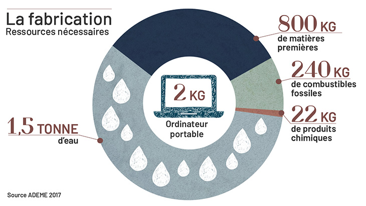

Les ressources nécessaires à la fabrication d’un ordinateur

## 2.1 Les centres de données

Les centres de données sont des infrastructures physiques (des lieux) permettant de stocker, de traiter et de partager de données immatérielles. Ces lieux regroupent des équipements constituants d’un système d’information tels que les ordinateurs, les serveurs, … C’est un lieu très sécurisé. Ces lieux fonctionnent de jour comme de nuit pour pouvoir répondre aux attentes du consommateur. Pour pouvoir fonctionner, les centres de données utilisent de l’électricité mais également des systèmes de climatisation pour éviter la surchauffe du matériel.

Ainsi les data-center consomment beaucoup d’énergie (Dumont, 2022).

## 2.2 Les réseaux

En réalité, les réseaux ne sont pas vraiment matériels. Pour qu’ils fonctionnent, il est nécessaire d’avoir de nombreux équipements informatiques comme des câbles, antennes, appareils numériques.

Lorsque qu’un individu fait des recherches sur le réseau, il consomme de l’énergie.

# 3 Les différents impacts environnementaux du numérique

## 3.1 Les émissions de gaz à effet de serres

Tout au long de leur vie, les appareils numériques émettent d’importantes émissions de CO2. Actuellement, ils sont responsables entre 2 % au niveau national et 4% au niveau international des émissions de gaz à effet de serre (Gouvernement, [sans date]).C’est plus que le domaine de l’aviation civile. Qu’est ce le l’effet de serre ? C’est un gaz présent dans l’atmosphère qui retient une partie de la chaleur reçue des rayons solaires. Celui-ci est indispenseable à la vie sur terre mais une augmentation trop importante entraine une hausse de température.

Les composants électroniques rejettent notamment des gaz fluorés comme le NF3 (trifluore d’azote)

## 3.2 La contamination chimique des eaux, des sols et de l’air

Afin de fabriquer les appareils numériques, l’industrie minière est sollicitée pour extraire différents minerais, plus ou moins rare. En effet, les composants électroniques peuvent être fabriqués grâce à de l’or, de l’étain, du tantale, du tungstène,… Cependant, lors de leur extraction, il y a de nombreux rejets toxiques qui entrainent la contamination du milieu: eaux, sols et air. Par exemple, les rivières de l’Amazonie sont pollués en partie à cause de l’industrie minière(Greenpeace, 2023).

## 3.3 L’érosion de la biodiversité et des sols

Afin de fabriquer les appareils numériques, des minerais sont recherchés. Ainsi, des mines se développent et détruisent leur environnement. Les sols sont détruits et de fait, la faune et la flore se déteriorent. Il y a une perte massive d’habitat.

# 4 Comment réduire son impact environnemental à cause du numérique?

A ce jour, il est possible de réduire son impact sur l’environnement. En effet, de nombreux gestes du quotidien sont réalisables et à la portée de tous.(Impact, 2021)

Une liste est présentée mais il est évident qu’il y a encore de nombreux autres gestes possibles (SCHLERET, 2020):

- Essayer de conserver au maximum ses appareils: Selon l’ADEME, il est possible d’améliorer de 50% le bilan carbone d’une machine en passant de 2 à 4 ans. En réalité, les personnes ont trop souvent tendance à remplacer leur appareil par un autre dès que celui-ci n’est plus récent ou q’une pièce est défectueuse. Or, dans la majorité des cas des appareils défectueux, il est possible de simplement remplacer une pièce.
- Ne pas toujours acheter neuf: de plus en plus de possibilités d’achat d’occasion ou de reconditionné existent aujourd’hui. Certes, les produits ne sont pas neufs mais dans la quasi totalité des cas, ce sont des appareils très opérationnels. Et surtout à des coûts plus interessant.
- Privilégier l’utilisation de wifi par rapport aux partages de connexion: en effet, d’après l’Université de Columbia (USA), le partage de connexion consomme 23 fois plus que la wifi (energic). Ainsi, lorsqu’on que personne a la possibilité de passer en Wifi, c’est la connexion à priviligier.
- Gérer les boites mails
- Réduire le nombre de notification
- Mieux gérer sa consommation streaming : plus la qualité de la vidéo sera élévée, plus la consommation d’énergie est importante.
- Eteindre les appareils connectés: lorsqu’une personne est absente de chez-elle, elle peut éteindre sa box.

# Bibliographie

ADEME, 2019. *Equipements électriques et électroniques : données 2019* [en ligne]. 2019. [Consulté le 8 février 2023]. Disponible à l'adresse : https://librairie.ademe.fr/dechets-economie-circulaire/4183-equipements-electriques-et-electroniques-donnees-2019.html

ARCEP, 2023. *L’empreinte environnementale du numérique* [en ligne]. février 2023. [Consulté le 8 février 2023]. Disponible à l'adresse : https://www.arcep.fr/la-regulation/grands-dossiers-thematiques-transverses/lempreinte-environnementale-du-numerique.html

DUMONT, Justine, 2022. *Quelle est l’empreinte carbone d’un data center ?* [en ligne]. septembre 2022. [Consulté le 8 février 2023]. Disponible à l'adresse : https://greenly.earth/fr-fr/blog/actualites-ecologie/quelle-est-l-empreinte-carbone-d-un-data-center

GOUVERNEMENT, [sans date]. *Ministères Écologie Énergie Territoires* [en ligne]. [Consulté le 8 février 2023]. Disponible à l'adresse : https://www.ecologie.gouv.fr/recherche

GREENPEACE, 2023. *Pollution numérique : comment la réduire ?* [en ligne]. février 2023. [Consulté le 8 février 2023]. Disponible à l'adresse : https://www.greenpeace.fr/la-pollution-numerique/

IMPACT, Improved, 2021. *La pollution numérique Improved impact* [en ligne]. septembre 2021. [Consulté le 8 février 2023]. Disponible à l'adresse : https://improved-impact.com/la-pollution-numerique/

INOXIA, 2021. *La fabrication, l’impact majeur du numérique sur l’environnement* [en ligne]. janvier 2021. [Consulté le 8 février 2023]. Disponible à l'adresse : https://www.inoxia.com/actualite/la-fabrication-l-impact-majeur-du-numerique-sur-l-environnement

SCHLERET, Bérénice, 2020. *Internet : 5 gestes simples pour réduire sa pollution numérique et limiter son impact sur l’environnement* [en ligne]. avril 2020. [Consulté le 8 février 2023]. Disponible à l'adresse : https://energic.io/blog/Internet-5-gestes-simples-pour-reduire-sa-pollution-numerique-et-limiter-son-impact-sur-l-environnement

WIKIPEDIA, 2022. *Ère de l’information* [en ligne]. octobre 2022. [Consulté le 8 février 2023]. Disponible à l'adresse : https://fr.wikipedia.org/w/index.php?title=%C3%88re_de_l%27information&oldid=198122280